# Verbos de dos tablas

Sesión 2

Luis F. Gomez L.

luis.gomezl@unimilitar.edu.co

Facultad de Estudios a Distancia

2026-09-28

# Preliminares

- Verificar:
  - ¿La carpeta `data` fue creada?
- Generar carpetas:
  - `011_verbos-dos-tablas-en-r`
    - Crear archivo `001_manipular-datos-dos-tabla.R`
- Descargar datos:
  - `resultados-saber-pro.rds`
  - `divipola-departamentos.rds`
  - `divipola-municipios.rds`
  - `programas-pregrado-faedis.rds`
    - Agregar en `data`

# Diagrama Entidad-Relación

- En el análisis de datos es habitual tener que **combinar dos o más tablas**.
- Esta necesidad surge del diseño propio de las **bases de datos relacionales** (Wickham 2023, cap. 19).
- Un **Diagrama Entidad-Relación** (Entity-Relationship Diagram - ERD) ilustra cómo un conjunto de tablas de una base de datos relacional se relacionan entre sí.
- Los diagramas ERD se componen de 3 elementos fundamentales:
  1. **Entidades**: representan cualquier objeto, concepto o evento.
  2. **Atributos**: características, rasgos o propiedades de cada entidad.
  3. **Relaciones**: asociación o vínculo lógico que existe entre dos o más entidades.

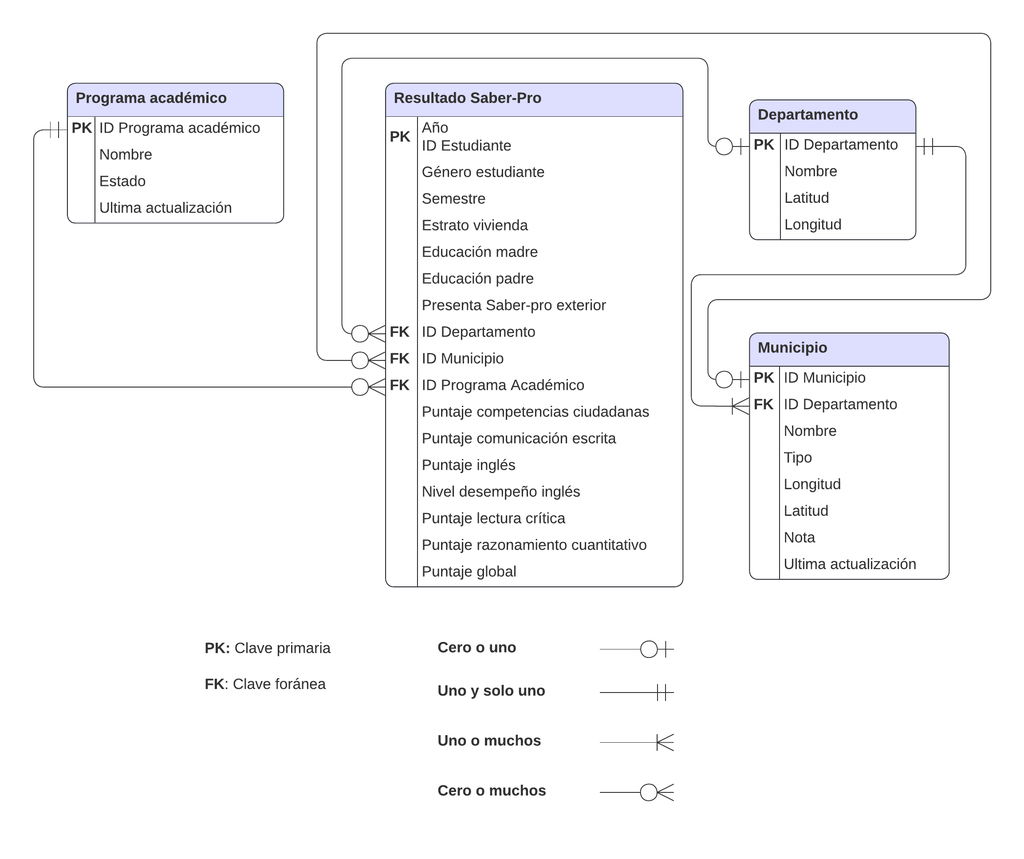

Figura 1: Diagrama Entidad-Relación con notación Crow’s Foot

## Entidades

En el modelo para analizar los resultados Saber-Pro de FAEDIS se definen 4 entidades:

1. **Resultado Saber-Pro**: modela el evento de un estudiante presentando las pruebas Saber-Pro en un periodo y lugar específico, junto con sus características socioeconómicas y resultados.
2. **Programa académico**: representa los programas académicos de pregrado de FAEDIS a los cuales puede potencialmente pertenecer un estudiante.
3. **Departamento**: división político-administrativa a nivel departamental según la codificación DIVIPOLA con información geográfica.
4. **Municipio**: división político-administrativa a nivel municipal según la codificación DIVIPOLA con información geográfica.

## Entidades

- A un elemento específico y concreto de una entidad se le denomina **instancia**.
- Ejemplos:
  - *Amazonas* es una instancia de la entidad **Departamento**.
  - *Cajicá* es una instancia de la entidad **Municipio**.
  - *Ingeniería Industrial* es una instancia de la entidad **Programa académico**.

## Atributos

- Los **atributos** son las características, rasgos o propiedades de cada entidad.
- Cada atributo se recopila en una **variable** y se almacena en una **columna** dentro de una tabla.
- Por ejemplo, la entidad **Departamento** se describe mediante:
  - `ID Departamento`: identificador único según DIVIPOLA.
  - `Nombre`: denominación oficial.
  - `Latitud` y `Longitud`: ubicación geográfica representativa.

## Atributos

### Clave primaria (Primary Key - PK)

- Atributo (o conjunto de atributos) que identifica de forma **única** cada registro dentro de una tabla.
- Reglas fundamentales:
  1. **Unicidad**: cada valor debe ser único en la tabla.
  2. **No nulidad**: no puede contener valores vacíos o ausentes (`NA` o `NULL`).
  3. **Inmutabilidad**: su valor no debe cambiar con el tiempo.
- Puede estar formada por una sola columna (p. ej. `ID Departamento` en **Departamento**) o por múltiples columnas (clave compuesta, p. ej. `Año` y `ID estudiante` en **Resultado Saber-Pro**).

## Atributos

### Clave foránea (Foreign Key - FK)

- Atributo en una tabla cuyos valores hacen referencia directa a la **clave primaria (PK)** de otra tabla.
- Es el **puente** que permite establecer una relación entre dos entidades y vincular datos sin duplicar información.
- **Diferencias clave respecto a la PK**:
  - Sus valores **sí se pueden repetir** en una tabla (muchos estudiantes presentan el examen en un mismo departamento).
  - **Sí puede contener valores ausentes (`NA`)** (p. ej., si un estudiante presenta el examen en el exterior no tiene asociado un departamento colombiano).

## Relaciones

### Cardinalidad

- Las relaciones definen cómo se vinculan lógicamente dos entidades a través de claves primarias y foráneas.
- La **cardinalidad** define las restricciones numéricas que gobiernan el vínculo lógico entre 2 entidades:

  > *¿Con cuántas instancias de una entidad `A` se puede vincular una instancia de la entidad `B`?*
- Se descompone en dos límites:
  - **Mínimo**: `0` (opcional) o `1` (obligatorio).
  - **Máximo**: `1` (uno) o `N` (muchos).

## Relaciones

### Notación Crow’s Foot (“Pata de cuervo”)

Tabla 1: Símbolos en la notación Crow’s Foot

| Símbolo | Representación gráfica | Descripción |
| --- | --- | --- |
| `0` |  | Cero (opcional) |
| `1` |  | Uno |
| `N` |  | Muchos |

## Relaciones

### Cardinalidad en notación Crow’s Foot

Tabla 2: Representación gráfica de la cardinalidad

| Cardinalidad | Representación gráfica | Significado |
| --- | --- | --- |
| `0` o `1` |  | Mínimo cero, máximo uno |
| `0` o `N` |  | Mínimo cero, máximo muchos |
| `1` y solo `1` |  | Mínimo uno, máximo uno |
| `1` o `N` |  | Mínimo uno, máximo muchos |

## Relaciones

# Gramática de manipulación de datos

## Verbos

En el paquete `dplyr`, existen 3 tipos de verbos para conectar o manipular dos tablas de datos:

1. **Mutating joins** (uniones de transformación): combinan variables de diferentes tablas correspondientes a 2 entidades.
2. **Filtering joins** (uniones de filtrado): buscan coincidencias entre registros afectando a las observaciones (filas), sin añadir variables.
3. **Set operations** (operaciones de conjuntos): tratan observaciones como conjuntos matemáticos (`intersect()`, `union()`, `setdiff()`).

   **Nota**

   Debido a que las **Set operations** no se requieren para los análisis que desarrollaremos a lo largo del curso, no se profundizará en ellas. No obstante, el lector interesado puede consultar la [documentación oficial](https://dplyr.tidyverse.org/reference/setops.html) de `dplyr` para conocer más detalles sobre este tipo de operaciones.

## Verbos

### Filtering joins

Existen dos tipos de uniones de filtrado:

- **`semi_join(x, y)`**: mantiene todas las observaciones de `x` que tienen una coincidencia en `y`.
- **`anti_join(x, y)`**: descarta todas las observaciones de `x` que tienen una coincidencia en `y` (mantiene las que **no** coinciden).

## Verbos

### Importar

```r
# Cargar paquetes ----
library(tidyverse)

# Importar datos ----
divipola_departamentos <- read_rds(
  file = "data/divipola-departamentos.rds"
)

resultado_saber_pro <- read_rds(
  file = "data/resultados-saber-pro.rds"
)
```

## Verbos

### Inspeccionar datos

```r
divipola_departamentos |>
  glimpse()
```

```
Rows: 33
Columns: 4
$ codigo   <chr> "05", "08", "11", "13", "15", "17", "18", "19", "20", "23", "…
$ nombre   <chr> "ANTIOQUIA", "ATLÁNTICO", "BOGOTÁ, D.C.", "BOLÍVAR", "BOYACÁ"…
$ latitud  <dbl> 6.7020321, 10.6770095, 4.3161077, 8.0797969, 5.8916729, 5.280…
$ longitud <dbl> -75.50456, -74.96522, -74.18107, -74.23515, -72.62788, -75.27…
```

## Verbos

### Inspeccionar datos

```r
resultado_saber_pro |>
  glimpse()
```

```
Rows: 1,239
Columns: 18
$ ano                         <int> 2021, 2021, 2021, 2021, 2021, 2021, 2021, …
$ estu_consecutivo            <chr> "EK202120262469", "EK202120116785", "EK202…
$ estu_genero                 <fct> M, M, M, M, F, F, F, F, F, F, F, F, M, F, …
$ estu_semestrecursa          <ord> 09, 09, 09, 09, 09, 09, 08, 09, 08, 08, 10…
$ fami_estratovivienda        <ord> Estrato 3, Estrato 4, Estrato 5, Estrato 4…
$ fami_educacionmadre         <ord> Técnica o tecnológica incompleta, Postgrad…
$ fami_educacionpadre         <ord> Secundaria (Bachillerato) completa, Postgr…
$ estu_exterior               <chr> "NO", "NO", "NO", "NO", "NO", "NO", "NO", …
$ estu_cod_depto_presentacion <chr> "11", "11", "11", "11", "11", "11", "11", …
$ estu_cod_mcpio_presentacion <chr> "11001", "11001", "11001", "11001", "11001…
$ estu_snies_prgmacademico    <int> 6527, 11428, 11428, 11428, 11428, 11428, 6…
$ mod_competen_ciudada_punt   <dbl> 162, 190, 154, 179, 178, 139, 143, 165, 12…
$ mod_comuni_escrita_punt     <dbl> 133, 174, 85, 157, 154, 131, 146, 137, 170…
$ mod_ingles_punt             <dbl> 151, 155, 150, 144, 142, 124, 162, 139, 11…
$ mod_ingles_desem            <ord> A2, A2, A2, A2, A2, A2, A2, A2, A1, A2, A2…
$ mod_lectura_critica_punt    <dbl> 114, 168, 139, 148, 188, 146, 161, 128, 12…
$ mod_razona_cuantitat_punt   <dbl> 135, 164, 113, 149, 166, 172, 143, 156, 12…
$ punt_global                 <dbl> 139, 170, 128, 155, 166, 142, 151, 145, 13…
```

## Verbos

### `semi_join()`

```r
# Departamentos con al menos un examen
semi_join(
  x = divipola_departamentos,
  y = resultado_saber_pro,
  by = join_by(
    codigo == estu_cod_depto_presentacion
  )
)
```

```
# A tibble: 24 × 4
   codigo nombre       latitud longitud
   <chr>  <chr>          <dbl>    <dbl>
 1 05     ANTIOQUIA      6.70     -75.5
 2 08     ATLÁNTICO     10.7      -75.0
 3 11     BOGOTÁ, D.C.   4.32     -74.2
 4 13     BOLÍVAR        8.08     -74.2
 5 15     BOYACÁ         5.89     -72.6
 6 17     CALDAS         5.28     -75.3
 7 18     CAQUETÁ        0.799    -74.0
 8 19     CAUCA          2.40     -76.8
 9 20     CESAR          9.54     -73.5
10 23     CÓRDOBA        8.36     -75.8
# ℹ 14 more rows
```

## Verbos

### `anti_join()`

```r
# Departamentos sin exámenes registrados
anti_join(
  x = divipola_departamentos,
  y = resultado_saber_pro,
  by = join_by(
    codigo == estu_cod_depto_presentacion
  )
)
```

```
# A tibble: 9 × 4
  codigo nombre     latitud longitud
  <chr>  <chr>        <dbl>    <dbl>
1 27     CHOCÓ        5.40     -76.9
2 44     LA GUAJIRA  11.5      -72.4
3 70     SUCRE        9.06     -75.1
4 81     ARAUCA       6.57     -71.0
5 91     AMAZONAS    -1.55     -71.5
6 94     GUAINÍA      2.73     -68.8
7 95     GUAVIARE     1.92     -72.1
8 97     VAUPÉS       0.646    -70.6
9 99     VICHADA      4.71     -69.4
```

## Mutating joins

Las **Mutating joins** permiten combinar variables de 2 tablas vinculando sus filas mediante claves:

1. **`inner_join()`**: conserva únicamente observaciones con coincidencia en **ambas** tablas (`x` y `y`).
2. **`left_join()`**: conserva todas las observaciones de la tabla izquierda (`x`), incorporando variables de la derecha (`y`).
3. **`right_join()`**: conserva todas las observaciones de la tabla derecha (`y`), incorporando variables de la izquierda (`x`).
4. **`full_join()`**: conserva todas las observaciones de **ambas** tablas (`x` y `y`), completando con `NA` donde no haya coincidencia.

## Mutating joins

### Ejemplo ilustrativo mínimo

```r
# Tabla x ----
x <- tibble(
  key = c(1, 2),
  z = c(3, 4)
)

x
```

```
# A tibble: 2 × 2
    key     z
  <dbl> <dbl>
1     1     3
2     2     4
```

```r
# Tabla y ----
y <- tibble(
  key = c(3, 1),
  a = 10,
  b = "s"
)

y
```

```
# A tibble: 2 × 3
    key     a b
  <dbl> <dbl> <chr>
1     3    10 s
2     1    10 s
```

## `inner_join()`

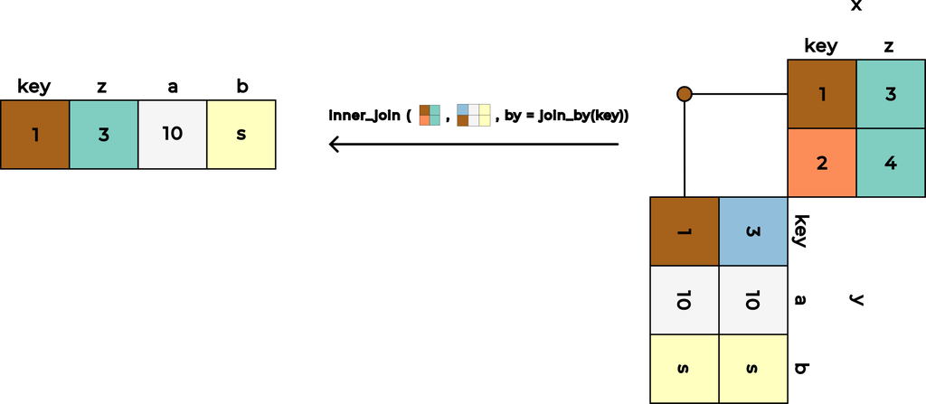

Figura 2: Representación gráfica de la función `inner_join()`

## `inner_join()`

```r
inner_join(
  x = x,
  y = y,
  by = join_by(key)
)
```

```
# A tibble: 1 × 4
    key     z     a b
  <dbl> <dbl> <dbl> <chr>
1     1     3    10 s
```

- Conserva únicamente la fila con `key = 1` (presente tanto en `x` como en `y`).
- Las filas con `key = 2` (en `x`) y `key = 3` (en `y`) se descartan automáticamente.

## `left_join()`

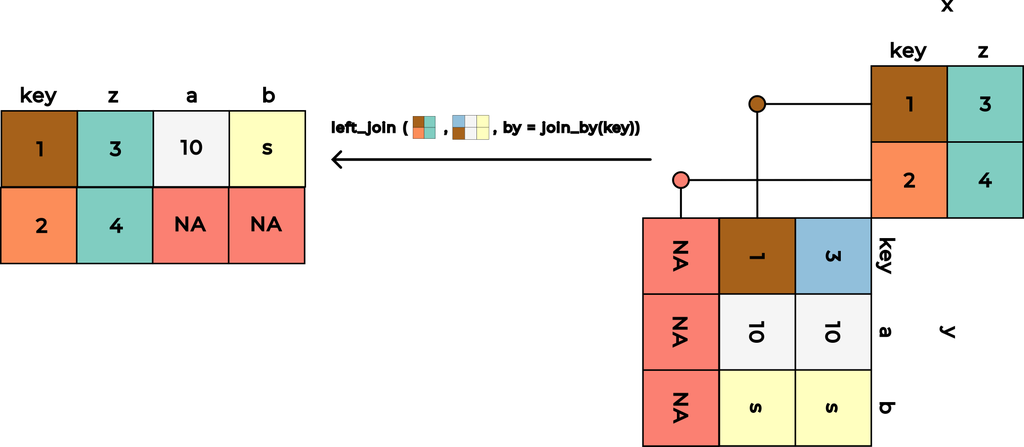

Figura 3: Representación gráfica de la función `left_join()`

## `left_join()`

```r
left_join(
  x = x,
  y = y,
  by = join_by(key)
)
```

```
# A tibble: 2 × 4
    key     z     a b
  <dbl> <dbl> <dbl> <chr>
1     1     3    10 s
2     2     4    NA <NA>
```

- Conserva todas las filas de `x` (`key = 1` y `key = 2`).
- Para `key = 1`, agrega los valores `a = 10` y `b = "s"`.
- Para `key = 2`, como no existe en `y`, rellena `a` y `b` con `NA`.

## `right_join()`

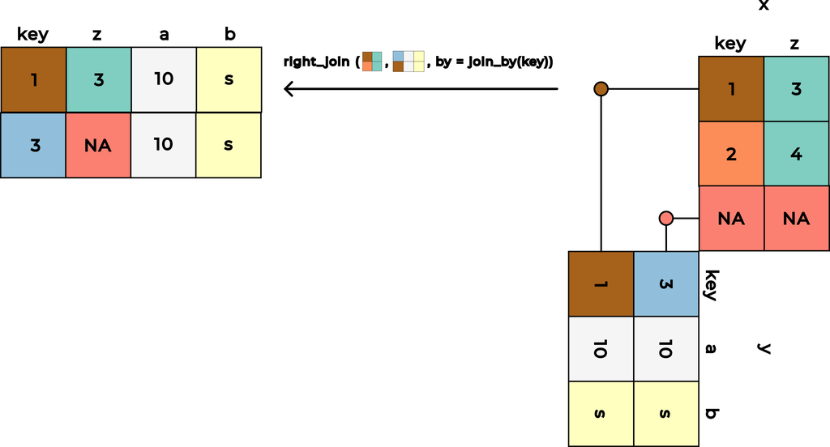

Figura 4: Representación gráfica de la función `right_join()`

## `right_join()`

```r
right_join(
  x = x,
  y = y,
  by = join_by(key)
)
```

```
# A tibble: 2 × 4
    key     z     a b
  <dbl> <dbl> <dbl> <chr>
1     1     3    10 s
2     3    NA    10 s
```

- Conserva todas las filas de `y` (`key = 3` y `key = 1`).
- Para `key = 3`, como no existe en `x`, rellena `z` con `NA`.
- Para `key = 1`, agrega el valor coincidente `z = 3`.

## `full_join()`

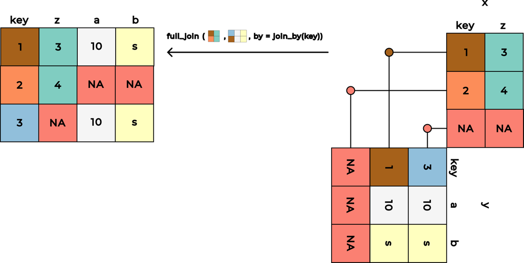

Figura 5: Representación gráfica de la función `full_join()`

## `full_join()`

```r
full_join(
  x = x,
  y = y,
  by = join_by(key)
)
```

```
# A tibble: 3 × 4
    key     z     a b
  <dbl> <dbl> <dbl> <chr>
1     1     3    10 s
2     2     4    NA <NA>
3     3    NA    10 s
```

- Conserva todas las filas de ambas tablas (`key = 1`, `key = 2` y `key = 3`).
- Los valores no coincidentes se completan con `NA` en las columnas correspondientes.

# Caso de estudio: consolidación de resultados Saber-Pro para FAEDIS

## Importar

```r
divipola_municipios <- read_rds(
  file = "data/divipola-municipios.rds"
)

programas_pregrado_faedis <- read_rds(
  file = "data/programas-pregrado-faedis.rds"
)
```

## Inspeccionar

```r
divipola_municipios |>
  glimpse()

programas_pregrado_faedis |>
  glimpse()
```

```
Rows: 1,122
Columns: 8
$ codigo_departamento  <chr> "05", "05", "05", "05", "05", "05", "05", "05", "…
$ codigo_municipio     <chr> "05001", "05002", "05004", "05021", "05030", "050…
$ nombre_municipio     <chr> "MEDELLÍN", "ABEJORRAL", "ABRIAQUÍ", "ALEJANDRÍA"…
$ tipo                 <chr> "Municipio", "Municipio", "Municipio", "Municipio…
$ longitud             <dbl> -75.58177, -75.42874, -76.06430, -75.14135, -75.7…
$ latitud              <dbl> 6.246631, 5.789315, 6.632282, 6.376061, 6.038708,…
$ notas                <chr> NA, NA, NA, NA, NA, NA, NA, NA, NA, NA, NA, NA, N…
$ ultima_actualizacion <date> 2025-12-30, 2025-12-30, 2025-12-30, 2025-12-30, …
```

```
Rows: 8
Columns: 4
$ codigo_snies_programa <int> 6527, 102005, 108241, 11428, 11004, 53703, 10514…
$ nombre_programa       <chr> "ADMINISTRACION DE EMPRESAS", "ADMINISTRACION DE…
$ estado_programa       <chr> "Activo", "Inactivo", "Activo", "Activo", "Activ…
$ ultima_actualizacion  <date> 2026-08-25, 2026-08-25, 2026-08-25, 2026-08-25,…
```

## Inconsistencia en datos del exterior

- En Data Icfes, cuando un estudiante presenta el examen en el exterior (`estu_exterior == "SI"`), se asigna por defecto el código de Bogotá.
- Esto genera una inconsistencia con el modelo relacional.

```r
resultado_saber_pro |>
  filter(estu_exterior == "SI") |>
  select(
    ano,
    estu_consecutivo,
    estu_exterior,
    estu_cod_depto_presentacion,
    estu_cod_mcpio_presentacion
  ) |>
  glimpse()
```

```
Rows: 64
Columns: 5
$ ano                         <int> 2021, 2021, 2021, 2021, 2021, 2021, 2021, …
$ estu_consecutivo            <chr> "EK202130321539", "EK202130321399", "EK202…
$ estu_exterior               <chr> "SI", "SI", "SI", "SI", "SI", "SI", "SI", …
$ estu_cod_depto_presentacion <chr> "11", "11", "11", "11", "11", "11", "11", …
$ estu_cod_mcpio_presentacion <chr> "11001", "11001", "11001", "11001", "11001…
```

## Función `replace_when()`

- `replace_when()` en `dplyr` permite actualizar de forma condicional los valores de un vector o columna:
  - `x`: vector o variable de entrada a modificar.
  - `...`: secuencia de fórmulas de dos lados (**two-sided formulas**) de la forma `condición ~ valor_de_reemplazo`:
    - **Lado izquierdo (LHS)**: condición lógica evaluada sobre cada observación (`TRUE`).
    - **Lado derecho (RHS)**: valor con el que se reemplazan las observaciones que cumplen la condición.
- Las observaciones que no cumplen la condición conservan automáticamente su valor original desde `x`.

## Ajuste de datos con `replace_when()`

```r
resultado_saber_pro_ajustado <- resultado_saber_pro |>
  mutate(
    estu_cod_depto_presentacion = replace_when(
      x = estu_cod_depto_presentacion,
      estu_exterior == "SI" ~ NA
    ),
    estu_cod_mcpio_presentacion = replace_when(
      x = estu_cod_mcpio_presentacion,
      estu_exterior == "SI" ~ NA
    )
  )
```

[output not shown]

## Verificación registros en Colombia

```r
# Registros en Colombia conservan sus códigos
resultado_saber_pro_ajustado |>
  filter(estu_exterior == "NO") |>
  select(
    ano,
    estu_consecutivo,
    estu_exterior,
    estu_cod_depto_presentacion,
    estu_cod_mcpio_presentacion
  ) |>
  glimpse()
```

```
Rows: 1,175
Columns: 5
$ ano                         <int> 2021, 2021, 2021, 2021, 2021, 2021, 2021, …
$ estu_consecutivo            <chr> "EK202120262469", "EK202120116785", "EK202…
$ estu_exterior               <chr> "NO", "NO", "NO", "NO", "NO", "NO", "NO", …
$ estu_cod_depto_presentacion <chr> "11", "11", "11", "11", "11", "11", "11", …
$ estu_cod_mcpio_presentacion <chr> "11001", "11001", "11001", "11001", "11001…
```

## Selección y filtro variables de interés

```r
programas_pregrado_faedis <- programas_pregrado_faedis |>
  filter(estado_programa == "Activo") |>
  select(
    codigo_snies_programa,
    nombre_programa
  )

divipola_departamentos <- divipola_departamentos |>
  select(
    codigo,
    nombre
  )

divipola_municipios <- divipola_municipios |>
  select(
    codigo_municipio,
    nombre_municipio
  )
```

## Uso secuencial `left_join()`

```r
resultado_saber_pro_ajustado <- resultado_saber_pro_ajustado |>
  left_join(
    y = programas_pregrado_faedis,
    by = join_by(
      estu_snies_prgmacademico == codigo_snies_programa
    )
  ) |>
  left_join(
    y = divipola_departamentos,
    by = join_by(
      estu_cod_depto_presentacion == codigo
    )
  ) |>
  left_join(
    y = divipola_municipios,
    by = join_by(
      estu_cod_mcpio_presentacion == codigo_municipio
    )
  )

resultado_saber_pro_ajustado |>
  glimpse()
```

```
Rows: 1,239
Columns: 21
$ ano                         <int> 2021, 2021, 2021, 2021, 2021, 2021, 2021, …
$ estu_consecutivo            <chr> "EK202120262469", "EK202120116785", "EK202…
$ estu_genero                 <fct> M, M, M, M, F, F, F, F, F, F, F, F, M, F, …
$ estu_semestrecursa          <ord> 09, 09, 09, 09, 09, 09, 08, 09, 08, 08, 10…
$ fami_estratovivienda        <ord> Estrato 3, Estrato 4, Estrato 5, Estrato 4…
$ fami_educacionmadre         <ord> Técnica o tecnológica incompleta, Postgrad…
$ fami_educacionpadre         <ord> Secundaria (Bachillerato) completa, Postgr…
$ estu_exterior               <chr> "NO", "NO", "NO", "NO", "NO", "NO", "NO", …
$ estu_cod_depto_presentacion <chr> "11", "11", "11", "11", "11", "11", "11", …
$ estu_cod_mcpio_presentacion <chr> "11001", "11001", "11001", "11001", "11001…
$ estu_snies_prgmacademico    <int> 6527, 11428, 11428, 11428, 11428, 11428, 6…
$ mod_competen_ciudada_punt   <dbl> 162, 190, 154, 179, 178, 139, 143, 165, 12…
$ mod_comuni_escrita_punt     <dbl> 133, 174, 85, 157, 154, 131, 146, 137, 170…
$ mod_ingles_punt             <dbl> 151, 155, 150, 144, 142, 124, 162, 139, 11…
$ mod_ingles_desem            <ord> A2, A2, A2, A2, A2, A2, A2, A2, A1, A2, A2…
$ mod_lectura_critica_punt    <dbl> 114, 168, 139, 148, 188, 146, 161, 128, 12…
$ mod_razona_cuantitat_punt   <dbl> 135, 164, 113, 149, 166, 172, 143, 156, 12…
$ punt_global                 <dbl> 139, 170, 128, 155, 166, 142, 151, 145, 13…
$ nombre_programa             <chr> "ADMINISTRACION DE EMPRESAS", "CONTADURIA …
$ nombre                      <chr> "BOGOTÁ, D.C.", "BOGOTÁ, D.C.", "BOGOTÁ, D…
$ nombre_municipio            <chr> "BOGOTÁ, D.C.", "BOGOTÁ, D.C.", "BOGOTÁ, D…
```

## Renombrar columnas agregadas

```r
resultado_saber_pro_ajustado <- resultado_saber_pro_ajustado |>
  rename(
    estu_prgm_academico = nombre_programa,
    estu_depto_presentacion = nombre,
    estu_mcpio_presentacion = nombre_municipio
  )

resultado_saber_pro_ajustado |>
  glimpse()
```

```
Rows: 1,239
Columns: 21
$ ano                         <int> 2021, 2021, 2021, 2021, 2021, 2021, 2021, …
$ estu_consecutivo            <chr> "EK202120262469", "EK202120116785", "EK202…
$ estu_genero                 <fct> M, M, M, M, F, F, F, F, F, F, F, F, M, F, …
$ estu_semestrecursa          <ord> 09, 09, 09, 09, 09, 09, 08, 09, 08, 08, 10…
$ fami_estratovivienda        <ord> Estrato 3, Estrato 4, Estrato 5, Estrato 4…
$ fami_educacionmadre         <ord> Técnica o tecnológica incompleta, Postgrad…
$ fami_educacionpadre         <ord> Secundaria (Bachillerato) completa, Postgr…
$ estu_exterior               <chr> "NO", "NO", "NO", "NO", "NO", "NO", "NO", …
$ estu_cod_depto_presentacion <chr> "11", "11", "11", "11", "11", "11", "11", …
$ estu_cod_mcpio_presentacion <chr> "11001", "11001", "11001", "11001", "11001…
$ estu_snies_prgmacademico    <int> 6527, 11428, 11428, 11428, 11428, 11428, 6…
$ mod_competen_ciudada_punt   <dbl> 162, 190, 154, 179, 178, 139, 143, 165, 12…
$ mod_comuni_escrita_punt     <dbl> 133, 174, 85, 157, 154, 131, 146, 137, 170…
$ mod_ingles_punt             <dbl> 151, 155, 150, 144, 142, 124, 162, 139, 11…
$ mod_ingles_desem            <ord> A2, A2, A2, A2, A2, A2, A2, A2, A1, A2, A2…
$ mod_lectura_critica_punt    <dbl> 114, 168, 139, 148, 188, 146, 161, 128, 12…
$ mod_razona_cuantitat_punt   <dbl> 135, 164, 113, 149, 166, 172, 143, 156, 12…
$ punt_global                 <dbl> 139, 170, 128, 155, 166, 142, 151, 145, 13…
$ estu_prgm_academico         <chr> "ADMINISTRACION DE EMPRESAS", "CONTADURIA …
$ estu_depto_presentacion     <chr> "BOGOTÁ, D.C.", "BOGOTÁ, D.C.", "BOGOTÁ, D…
$ estu_mcpio_presentacion     <chr> "BOGOTÁ, D.C.", "BOGOTÁ, D.C.", "BOGOTÁ, D…
```

## Reubicar columnas con `relocate()`

```r
resultado_saber_pro_ajustado <- resultado_saber_pro_ajustado |>
  relocate(
    estu_prgm_academico,
    .after = estu_snies_prgmacademico
  ) |>
  relocate(
    estu_depto_presentacion,
    .after = estu_cod_depto_presentacion
  ) |>
  relocate(
    estu_mcpio_presentacion,
    .after = estu_cod_mcpio_presentacion
  )

resultado_saber_pro_ajustado |>
  glimpse()
```

```
Rows: 1,239
Columns: 21
$ ano                         <int> 2021, 2021, 2021, 2021, 2021, 2021, 2021, …
$ estu_consecutivo            <chr> "EK202120262469", "EK202120116785", "EK202…
$ estu_genero                 <fct> M, M, M, M, F, F, F, F, F, F, F, F, M, F, …
$ estu_semestrecursa          <ord> 09, 09, 09, 09, 09, 09, 08, 09, 08, 08, 10…
$ fami_estratovivienda        <ord> Estrato 3, Estrato 4, Estrato 5, Estrato 4…
$ fami_educacionmadre         <ord> Técnica o tecnológica incompleta, Postgrad…
$ fami_educacionpadre         <ord> Secundaria (Bachillerato) completa, Postgr…
$ estu_exterior               <chr> "NO", "NO", "NO", "NO", "NO", "NO", "NO", …
$ estu_cod_depto_presentacion <chr> "11", "11", "11", "11", "11", "11", "11", …
$ estu_depto_presentacion     <chr> "BOGOTÁ, D.C.", "BOGOTÁ, D.C.", "BOGOTÁ, D…
$ estu_cod_mcpio_presentacion <chr> "11001", "11001", "11001", "11001", "11001…
$ estu_mcpio_presentacion     <chr> "BOGOTÁ, D.C.", "BOGOTÁ, D.C.", "BOGOTÁ, D…
$ estu_snies_prgmacademico    <int> 6527, 11428, 11428, 11428, 11428, 11428, 6…
$ estu_prgm_academico         <chr> "ADMINISTRACION DE EMPRESAS", "CONTADURIA …
$ mod_competen_ciudada_punt   <dbl> 162, 190, 154, 179, 178, 139, 143, 165, 12…
$ mod_comuni_escrita_punt     <dbl> 133, 174, 85, 157, 154, 131, 146, 137, 170…
$ mod_ingles_punt             <dbl> 151, 155, 150, 144, 142, 124, 162, 139, 11…
$ mod_ingles_desem            <ord> A2, A2, A2, A2, A2, A2, A2, A2, A1, A2, A2…
$ mod_lectura_critica_punt    <dbl> 114, 168, 139, 148, 188, 146, 161, 128, 12…
$ mod_razona_cuantitat_punt   <dbl> 135, 164, 113, 149, 166, 172, 143, 156, 12…
$ punt_global                 <dbl> 139, 170, 128, 155, 166, 142, 151, 145, 13…
```

## Exportar datos consolidados

```r
# Exportar archivo ajustado ----
resultado_saber_pro_ajustado |>
  write_rds(
    file = "data/2021-2024_saber-pro-genericas_faedis_ajustado.rds"
  )
```

Gracias

# Referencias

Wickham, Hadley. 2023. *R for Data Science*. 2.ª ed. O’Reilly Media, Incorporated. https://r4ds.hadley.nz/.